# Normal test

Redkokosh Kirilll

12/23/2021

```r
library(dplyr)
library(lattice)
library(tidyr)
library(GGally)
library(ggpubr)
library(lm.beta)
library(MASS)
library(rstatix)
library(REdaS)
library(psych)
```

```r
df <- read.csv("table1.csv", header = TRUE, as.is = FALSE, sep = ';')
head(df)
```

```
##         Имя Есть.педагогика.в.УП. Вид.записи Структурное.подразделение курс
## 1     Элина                  есть         пз                      ЕИСН    4
## 2    Зарина                  есть         пз                      ИПОМ    4
## 3   Татьяна                  есть         сз                      АСиА    1
## 4 Гюльбахар                  есть         пз                      ИПОМ    3
## 5 Александр                   нет         сз                       ФТИ    4
## 6    Ленура                  есть         сз                       ФТИ    1
##   б.с.м ТЦК_binary ТЦК_балл Уровень.сформированности СЦК_старт   Т1  Т2 Т3   Т4
## 1     б          1       67              продвинутый      8.00 0.57 0.6  1 0.33
## 2     б          1       26                начальный        NA 1.00 1.0  1 1.00
## 3     м          1       75                  высокий      8.67 1.00 1.0  1 1.00
## 4     б          1       49                  базовый     10.67 1.00 1.0  1 1.00
## 5     б          1       77                  высокий      5.00 0.86 0.8  1 1.00
## 6     м          1       80                  высокий     11.67 0.86 0.8  1 1.00
##     Т5 П2 Т6   Т7   Т8   Т9  Т10  Т11 П4 П5 П6 П8 П9 СЦК_финал ИТ_В1 ИТ_В2
```

[output cut: 20 more lines]

```r
#lm.df.oecd <- lm.beta(lm(data = df, ИТ_max ~ Т1 + Т2 + Т3 + Т4 + Т5 + Т6 + Т7 + Т8 + Т9 + Т10 + Т11 + П2 + П4 + П5 + П6 + П8 + П9))
#summary(lm.df.oecd)
#stepAIC(lm.df.oecd, direction = "backward")
```

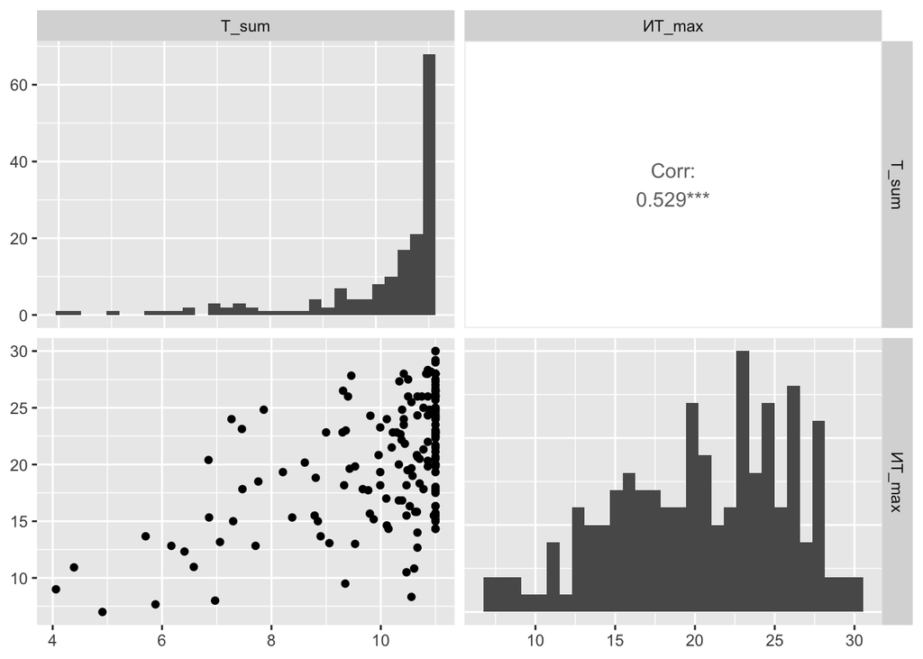

```r
df <- df %>% mutate(T_sum = Т1 + Т2 + Т3 + Т4 + Т5 + Т6 + Т7 + Т8 + Т9 + Т10 + Т11)
df <- df %>% mutate(П_sum = (П2 + П4 + П5 + П6 + П8 + П9))
ggpairs(df, columns = c('T_sum', 'ИТ_max'), diag = list(continuous = "barDiag"))
```

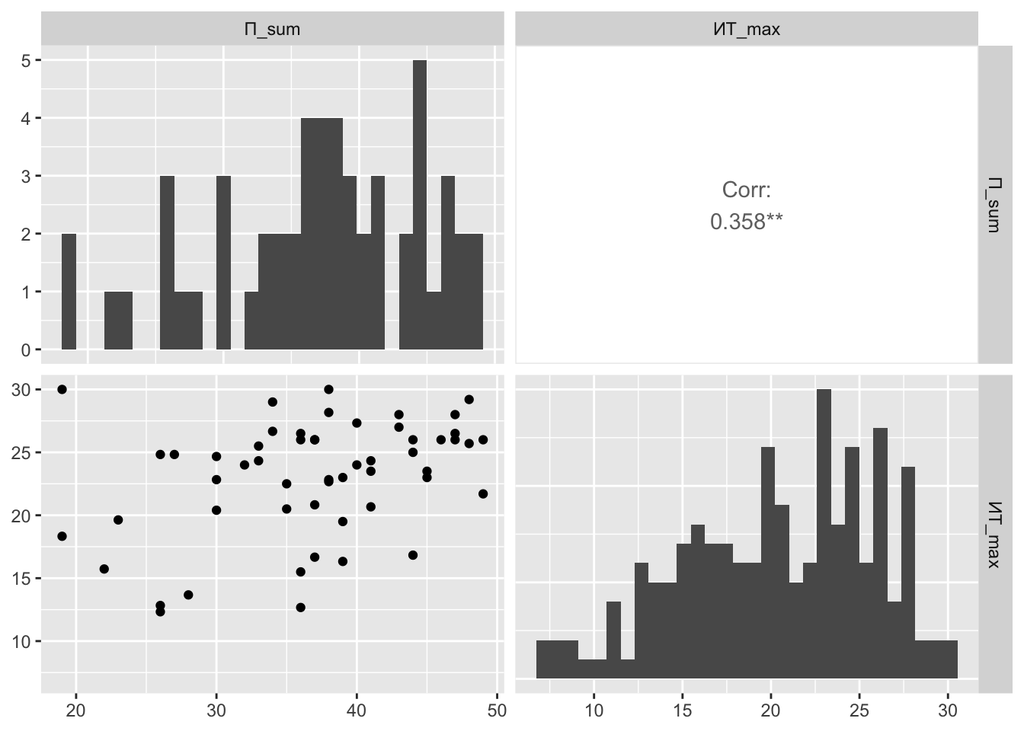

```r
ggpairs(df, columns = c('П_sum', 'ИТ_max'), diag = list(continuous = "barDiag"))
```

1. Корреляция суммы оценок за тесты и оценки за итоговый тест = 0.5288 (значима = 2.029e-13 при стандартных уровнях значимости) (индивидов- 166).
2. Корреляция суммы оценок за практикумы и оценки за итоговый тест = 0.3582 (значима = 0.0078 при стандартных уровнях значимости) (индивидов- 53).

У оценок за тесты очень интересное распределение, корреляция тут вроде большая и даже значимая, но распределение немного вводит в ступор…

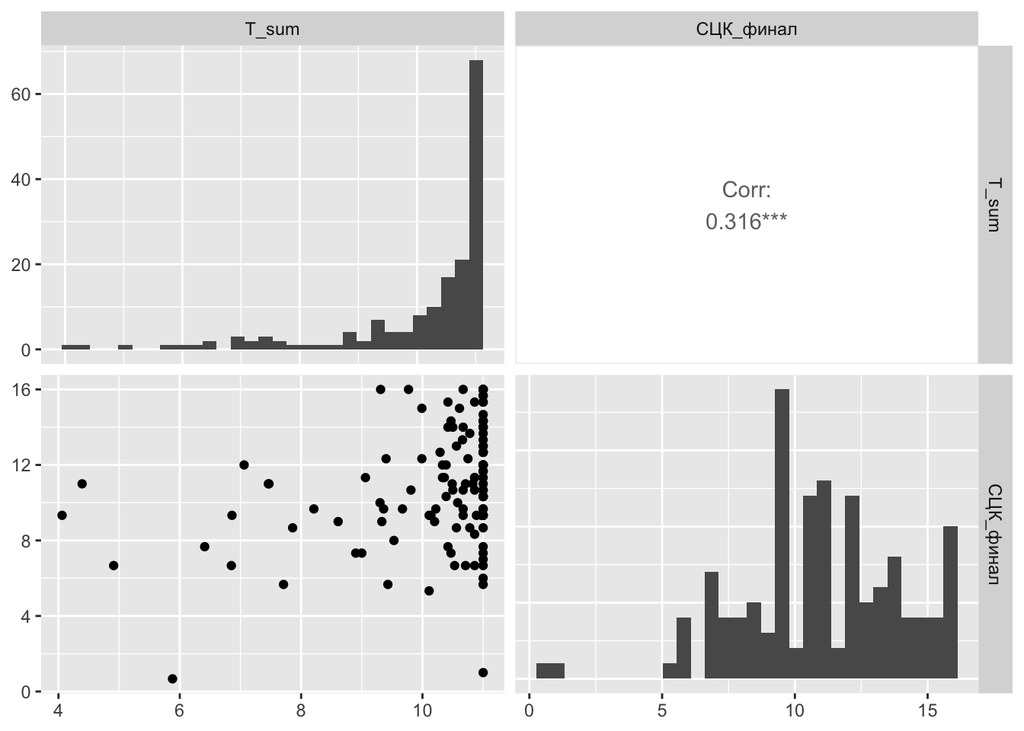

```r
ggpairs(df, columns = c('T_sum', 'СЦК_финал'), diag = list(continuous = "barDiag"))
```

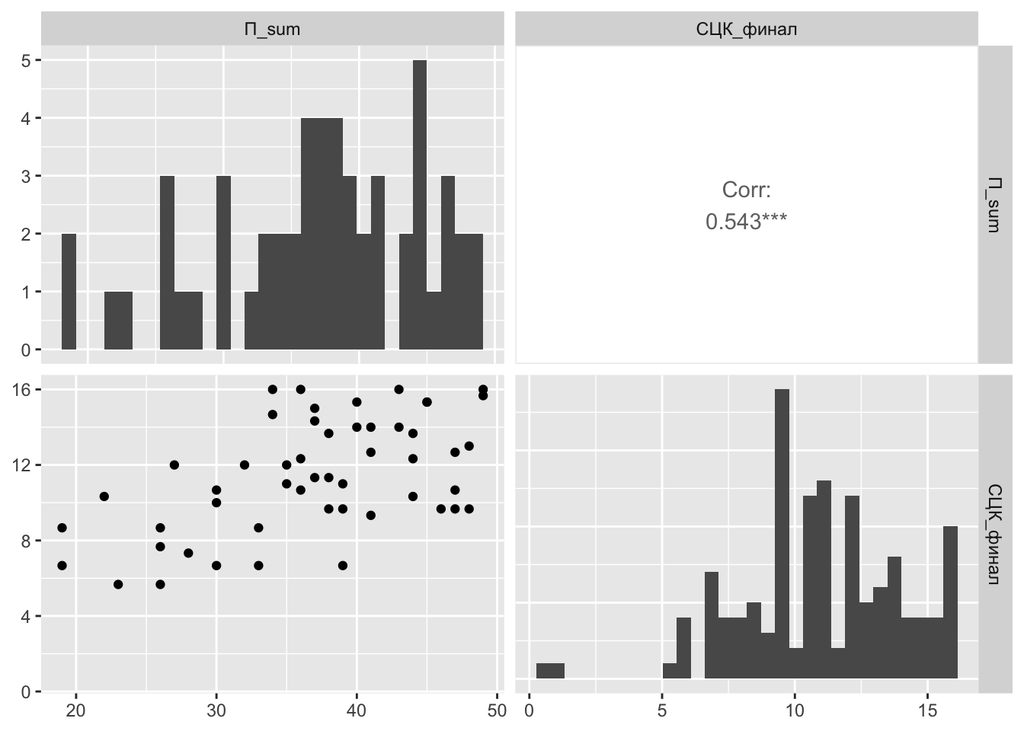

```r
ggpairs(df, columns = c('П_sum', 'СЦК_финал'), diag = list(continuous = "barDiag"))
```

1. Корреляция суммы оценок за тесты и финальной СЦК = 0.3155 (значима = 0.0003 при стандартных уровнях значимости) (индивидов- 126).
2. Корреляция суммы оценок за практикумы и финальной СЦК = 0.5433 (значима = 3.782e-05 при стандартных уровнях значимости) (индивидов- 50).

Похоже, что есть хоть какая-то связь только во втором случае.

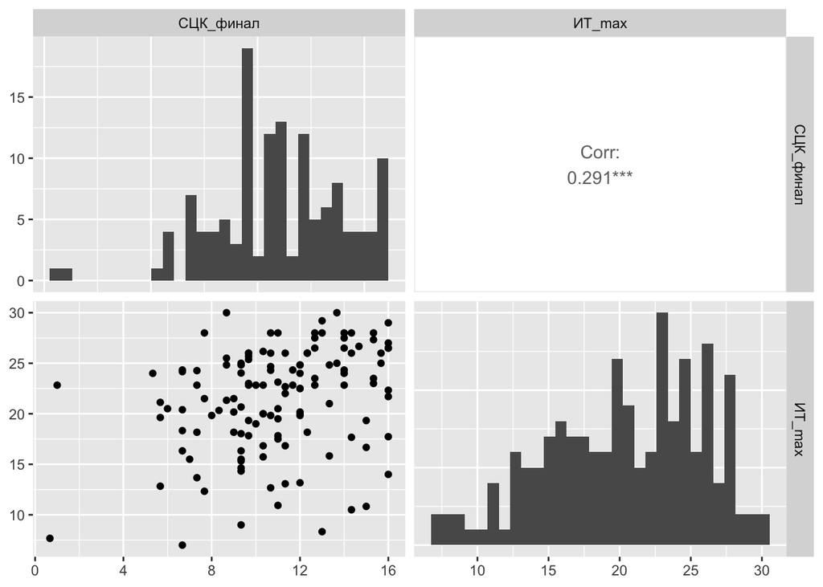

```r
ggpairs(df, columns = c('СЦК_финал', 'ИТ_max'), diag = list(continuous = "barDiag"))
```

Между итоговой оценкой и финальной самооценкой присутствует значимая, положительная корреляция 0.29. На графике (левый верхний) видно, что люди часто оценивают себя выше среднего. А реальной зависимости (левый нижний)– нет, это равномерное распределение с парой выбросов.

```r
df$ИТ_max <- (10/3)*df$ИТ_max
df <- df %>% mutate(group = ifelse(df$Вид.записи == 'пз', 1, 2))
df$group <- as.factor(df$group)
group1 <- subset(df, group == 1)
group2 <- subset(df, group == 2)
```

```r
group1 <- group1 %>% mutate(group11 = ifelse( (ИТ_max > 60), ifelse( (ИТ_max > 74) , "3", "2"), "1"))
group1$group11 <- as.factor(group1$group11)
group2 <- group2 %>% mutate(group21 = ifelse( (ИТ_max > 60), ifelse( (ИТ_max > 74) , "3", "2"), "1"))
group2$group21 <- as.factor(group2$group21)
mice <- matrix(c(nrow(filter(group1, group11 == '1')), nrow(filter(group1, group11 == '2')), nrow(filter(group1, group11 == '3')), nrow(filter(group2, group21 == '1')), nrow(filter(group2, group21 == '2')), nrow(filter(group2, group21 == '3'))), nrow = 2, byrow = TRUE)
mice
```

```
##      [,1] [,2] [,3]
## [1,]   32   23   36
## [2,]   26   18   42
```

```r
chisq.test(mice)
```

```
##
##  Pearson's Chi-squared test
##
## data:  mice
## X-squared = 1.552, df = 2, p-value = 0.4602
```

Распределения итоговой оценки при группировке ± равны, значит вряд ли есть “корреляция”.

```r
df1 <- na.omit(dplyr::select(df, курс, ТЦК_балл, СЦК_старт, Т1, Т2, Т3, Т4, Т5, Т6, Т7, Т8, Т9, Т10, Т11, СЦК_финал, ИТ_max))
KMOS(df1, use = "pairwise.complete.obs")
```

```
##
## Kaiser-Meyer-Olkin Statistics
##
## Call: KMOS(x = df1, use = "pairwise.complete.obs")
##
## Measures of Sampling Adequacy (MSA):
##      курс  ТЦК_балл СЦК_старт        Т1        Т2        Т3        Т4        Т5
## 0.4837355 0.7369335 0.6264580 0.9046298 0.9137771 0.8049618 0.8772477 0.9472604
##        Т6        Т7        Т8        Т9       Т10       Т11 СЦК_финал    ИТ_max
## 0.8216542 0.9307633 0.8485435 0.9049964 0.8652982 0.7969639 0.8088970 0.8843128
##
## KMO-Criterion: 0.8657223
```

```r
cortest.bartlett(cor(df1))
```

```
## $chisq
## [1] 868.2416
##
## $p.value
## [1] 1.009222e-113
##
## $df
## [1] 120
```

```r
factanal(df1, 4)
```

```
##
## Call:
## factanal(x = df1, factors = 4)
##
## Uniquenesses:
##      курс  ТЦК_балл СЦК_старт        Т1        Т2        Т3        Т4        Т5
##     0.742     0.734     0.718     0.616     0.211     0.499     0.224     0.360
##        Т6        Т7        Т8        Т9       Т10       Т11 СЦК_финал    ИТ_max
##     0.205     0.338     0.067     0.484     0.216     0.400     0.681     0.612
##
## Loadings:
##           Factor1 Factor2 Factor3 Factor4
## курс      -0.128  -0.161           0.463
## ТЦК_балл   0.128   0.480  -0.134
## СЦК_старт          0.527
## Т1         0.451   0.407   0.105
## Т2         0.805   0.342   0.117  -0.103
## Т3         0.316   0.146   0.291   0.543
## Т4         0.788   0.218   0.272   0.184
## Т5         0.762   0.134   0.180
## Т6         0.559   0.391  -0.175   0.547
## Т7         0.754   0.166   0.115   0.228
## Т8         0.646           0.706
## Т9         0.661   0.182   0.197
## Т10        0.839   0.141   0.245
## Т11        0.443           0.600   0.187
## СЦК_финал  0.157   0.493   0.214
## ИТ_max     0.390   0.467   0.129
##
##                Factor1 Factor2 Factor3 Factor4
## SS loadings      5.000   1.615   1.302   0.977
## Proportion Var   0.312   0.101   0.081   0.061
## Cumulative Var   0.312   0.413   0.495   0.556
##
## Test of the hypothesis that 4 factors are sufficient.
## The chi square statistic is 98.43 on 62 degrees of freedom.
## The p-value is 0.00222
```

Интерпретация:

Фактор 1 объединяет почти все тесты (кроме 3 и 11 (хотя там тоже неплохие корреляции)), то есть можно сказать, что наиболее влияющим фактором является прохождение тестов.

Фактор 2 объединяет ТЦК, СЦК_старт, СЦК_финал и ИТ_max.

Дальше в факторах уже что-то неинтресное происходит. Но факторный анализ разделил оценки за тесты и оценки ТЦК, СЦК_старт, СЦК_финал и ИТ_max, то есть это как бы различные оценки, а также самый влияющий фактор– прохождение тестов.

```r
df1 <- rbind(dplyr::select(group1, ИТ_max, group), dplyr::select(group2, ИТ_max, group))
res.aov <- df1 %>% anova_test(ИТ_max ~ group)
res.aov
```

```
## ANOVA Table (type II tests)
##
##   Effect DFn DFd     F     p p<.05   ges
## 1  group   1 175 1.142 0.287       0.006
```

```r
df1 <- rbind(dplyr::select(group1, ИТ_max, T_sum), dplyr::select(group2, ИТ_max, T_sum))
res.aov <- df1 %>% anova_test(ИТ_max ~ T_sum)
res.aov
```

```
## ANOVA Table (type II tests)
##
##   Effect DFn DFd      F        p p<.05  ges
## 1  T_sum   1 165 64.073 2.03e-13     * 0.28
```

```r
df1 <- rbind(dplyr::select(group1, ИТ_max, П_sum), dplyr::select(group2, ИТ_max, П_sum))
res.aov <- df1 %>% anova_test(ИТ_max ~ П_sum)
res.aov
```

```
## ANOVA Table (type II tests)
##
##   Effect DFn DFd     F     p p<.05   ges
## 1  П_sum   1  52 7.658 0.008     * 0.128
```

```r
df <- df %>% mutate(group = ifelse(df$Есть.педагогика.в.УП. == 'есть', 1, 2))
df$group <- as.factor(df$group)
group1 <- subset(df, group == 1)
group2 <- subset(df, group == 2)
df1 <- rbind(dplyr::select(group1, ИТ_max, group), dplyr::select(group2, ИТ_max, group))
res.aov <- df1 %>% anova_test(ИТ_max ~ group)
res.aov
```

```
## ANOVA Table (type II tests)
##
##   Effect DFn DFd     F     p p<.05   ges
## 1  group   1 175 1.072 0.302       0.006
```

Итоговая оценка и сумма оценок за тесты, ges = 0.28, p-value = 2.03e-13.

Итоговая оценка и сумма оценок за практикумы, ges = 0.128, p-value = 0.008.

Итоговая оценка и вид записи, ges = 0.006, p-value = 0.287.

Итоговая оценка и наличие пед. дисциплин, ges = 0.006, p-value = 0.302.

Значимыми являются первые два результата, при этом сумма оценок за тесты объясняет около 28% итоговой оценки, а сумма оценок за практикумы 13%, то есть тесты больше влияют на оценку за итоговый тест.

```r
df1 <- rbind(dplyr::select(group1, СЦК_финал, group), dplyr::select(group2, СЦК_финал, group))
res.aov <- df1 %>% anova_test(СЦК_финал ~ group)
res.aov
```

```
## ANOVA Table (type II tests)
##
##   Effect DFn DFd     F     p p<.05   ges
## 1  group   1 129 2.267 0.135       0.017
```

```r
df1 <- rbind(dplyr::select(group1, СЦК_финал, T_sum), dplyr::select(group2, СЦК_финал, T_sum))
res.aov <- df1 %>% anova_test(СЦК_финал ~ T_sum)
res.aov
```

```
## ANOVA Table (type II tests)
##
##   Effect DFn DFd      F        p p<.05 ges
## 1  T_sum   1 125 13.827 0.000301     * 0.1
```

```r
df1 <- rbind(dplyr::select(group1, СЦК_финал, П_sum), dplyr::select(group2, СЦК_финал, П_sum))
res.aov <- df1 %>% anova_test(СЦК_финал ~ П_sum)
res.aov
```

```
## ANOVA Table (type II tests)
##
##   Effect DFn DFd     F        p p<.05   ges
## 1  П_sum   1  49 20.53 3.78e-05     * 0.295
```

```r
df <- df %>% mutate(group = ifelse(df$Вид.записи == 'пз', 1, 2))
df$group <- as.factor(df$group)
group1 <- subset(df, group == 1)
group2 <- subset(df, group == 2)
df1 <- rbind(dplyr::select(group1, СЦК_финал, group), dplyr::select(group2, СЦК_финал, group))
res.aov <- df1 %>% anova_test(СЦК_финал ~ group)
res.aov
```

```
## ANOVA Table (type II tests)
##
##   Effect DFn DFd     F     p p<.05   ges
## 1  group   1 129 2.199 0.141       0.017
```

```r
df1 <- rbind(dplyr::select(group1, СЦК_финал, ИТ_max), dplyr::select(group2, СЦК_финал, ИТ_max))
res.aov <- df1 %>% anova_test(ИТ_max ~ СЦК_финал)
res.aov
```

```
## ANOVA Table (type II tests)
##
##      Effect DFn DFd     F        p p<.05   ges
## 1 СЦК_финал   1 129 11.91 0.000755     * 0.085
```

СЦК_финал и сумма оценок за тесты, ges = 0.1, p-value = 0.000301.

СЦК_финал и сумма оценок за практикумы, ges = 0.295, p-value = 3.78e-05.

СЦК_финал и вид записи, ges = 0.017, p-value = 0.141.

СЦК_финал и наличие пед. дисциплин, ges = 0.017, p-value = 0.135.

Значимыми являются первые два результата, при этом сумма оценок за практикумы объясняет около 30% СЦК_финал, а сумма оценок за тесты 10%, то есть практикумы больше влияют на итоговую самооценку.